# Project 1

Project 1 Group 1 – Michelle, Valentina, Ian

Due date: March 23 2025 at midnight (EST)

## Overview

In this project, you will produce an exploratory data analysis (EDA) report for the `NHANES::NHANESraw` dataset. **Warning:** You are not allowed to use the `NHANES::NHANES` dataset.

[output not shown]

```
## # A tibble: 20,293 × 78
##       ID SurveyYr Gender   Age AgeMonths Race1    Race3 Education  MaritalStatus
##    <int> <fct>    <fct>  <int>     <int> <fct>    <fct> <fct>      <fct>
##  1 51624 2009_10  male      34       409 White    <NA>  High Scho… Married
##  2 51625 2009_10  male       4        49 Other    <NA>  <NA>       <NA>
##  3 51626 2009_10  male      16       202 Black    <NA>  <NA>       <NA>
##  4 51627 2009_10  male      10       131 Black    <NA>  <NA>       <NA>
##  5 51628 2009_10  female    60       722 Black    <NA>  High Scho… Widowed
##  6 51629 2009_10  male      26       313 Mexican  <NA>  9 - 11th … Married
##  7 51630 2009_10  female    49       596 White    <NA>  Some Coll… LivePartner
##  8 51631 2009_10  female     1        12 White    <NA>  <NA>       <NA>
##  9 51632 2009_10  male      10       124 Hispanic <NA>  <NA>       <NA>
## 10 51633 2009_10  male      80        NA White    <NA>  Some Coll… Married
## # ℹ 20,283 more rows
## # ℹ 69 more variables: HHIncome <fct>, HHIncomeMid <int>, Poverty <dbl>,
## #   HomeRooms <int>, HomeOwn <fct>, Work <fct>, Weight <dbl>, Length <dbl>,
## #   HeadCirc <dbl>, Height <dbl>, BMI <dbl>, BMICatUnder20yrs <fct>,
## #   BMI_WHO <fct>, Pulse <int>, BPSysAve <int>, BPDiaAve <int>, BPSys1 <int>,
## #   BPDia1 <int>, BPSys2 <int>, BPDia2 <int>, BPSys3 <int>, BPDia3 <int>,
## #   Testosterone <dbl>, DirectChol <dbl>, TotChol <dbl>, UrineVol1 <int>, …
```

## Instruction

1. Define a set of questions/tasks that will guide your exploration.

# Question 1: Is there an age of peak perceived health?

A facet grid mapping age by decade and gender with level of self-reported general health explores this question.

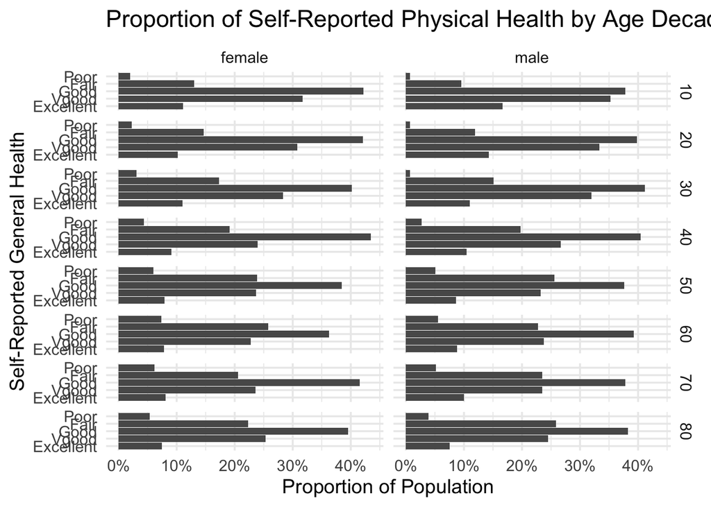

The trend in the figure above suggests that as age increases, the proportion of people who report good, very good, or excellent health slightly decreases in both males and females. The proportion of women reporting poor health is always higher than that of men at any decade. Less than 5% of men in their 80’s report poor physical health while the percent of women is above 5%.

# Question 2: Are a larger amount of pregnancies total associated with worse sleep?

To investigate whether a larger amount of pregnancies has an association with worse perceived sleep, a scatter plot of average sleep quality vs. number of pregnancies was made.

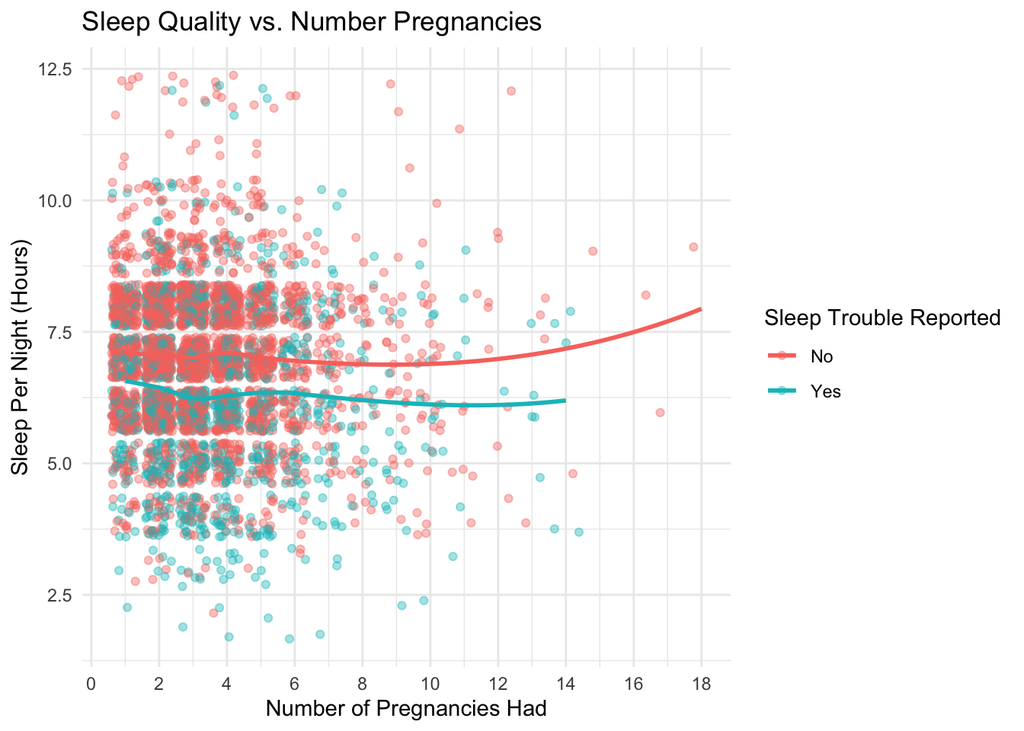

As the number of pregnancies increases, the trendline shows a relatively small increase for people who report no sleep trouble, and no trend for those who do not. However, some of this increase in those without sleep trouble could be attributed to a small sample of women who have had greater than 10 pregnancies. This graph also reveals that the average level of sleep among women who have had a pregnancy is one approximately one hour higher on average for those who do not report sleep trouble than those who do. It could be interesting to investigate this trend further on a population level.

# Question 3: How is blood pressure associated with age?

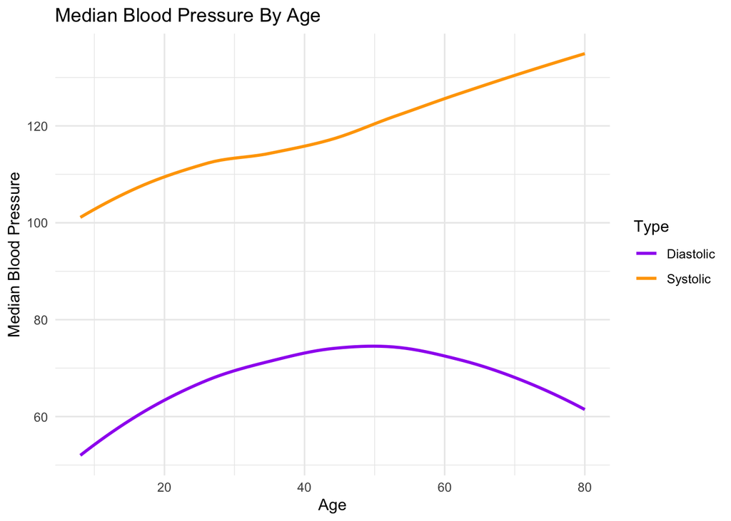

Systolic blood pressure increases with age with a near linear trend, while diastolic peaks around age 50 and falls back in a quadratic pattern. The average systolic pressure has a larger positive slope after age 40 than before, so it rises more rapidly.

# Question 4: How is blood pressure related with BMI?

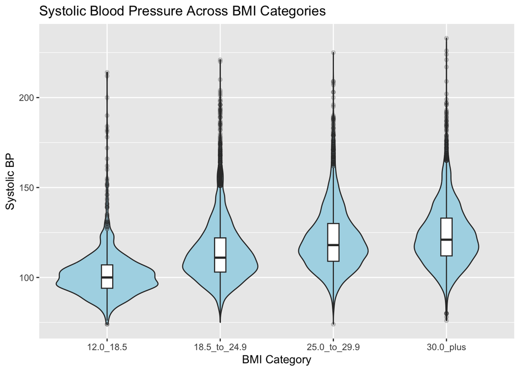

We wanted to explore the relationship between BMI and blood pressure, so we created a violin plot in order to visualize how systolic blood pressure changes for each BMI range. From this graph, we can see that as BMI increases, the distribution of systolic blood pressures also slightly increases. For a BMI range of 12.0 - 18.5, we can see that the majority of people have a systolic blood pressure around 100. However, for a BMI range of 18.5 - 24.9, we can see that the majority of people have a systolic blood pressure around 110. Additionally, for a BMI range of 25.0 to 29.9 or 30.0+, we can see that the majority of people have a systolic blood pressure around 120.

# Question 5: Do people with higher incomes typically have better mental health?

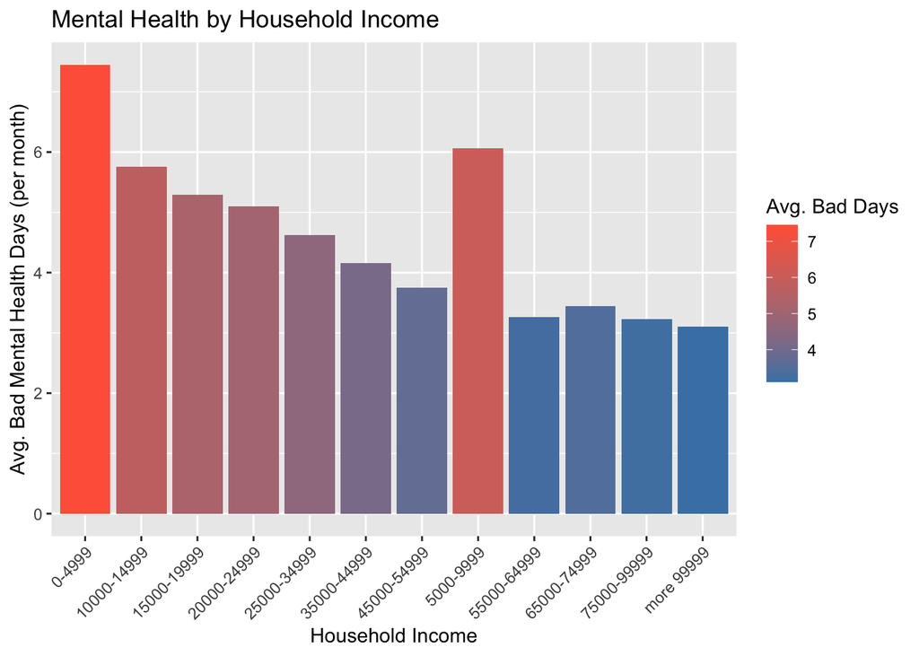

They say money can’t buy happiness, but is this true? The guiding question for this graph was “Do people with higher incomes typically have better mental health”? The way that we decided to explore this problem is first by selecting a subset of our data only containing the columns Age >= 18, HHIncome, DaysMentalHlthBad, and Depressed. We then grouped the items based on HHIncome, and created a new column representing the average number of bad days each group experiences. We then graphed this data using a bar chart, with the x-axis being HHIncome, the y-axis being average number of bad days, and we also color-coded the columns based on how good or bad they are (with blue indicating less and red indicating more). From this, we can tell that as income increases, the average number of bad days tends to decrease, except for the 5000-9999 range, which has the second highest number of bad days.

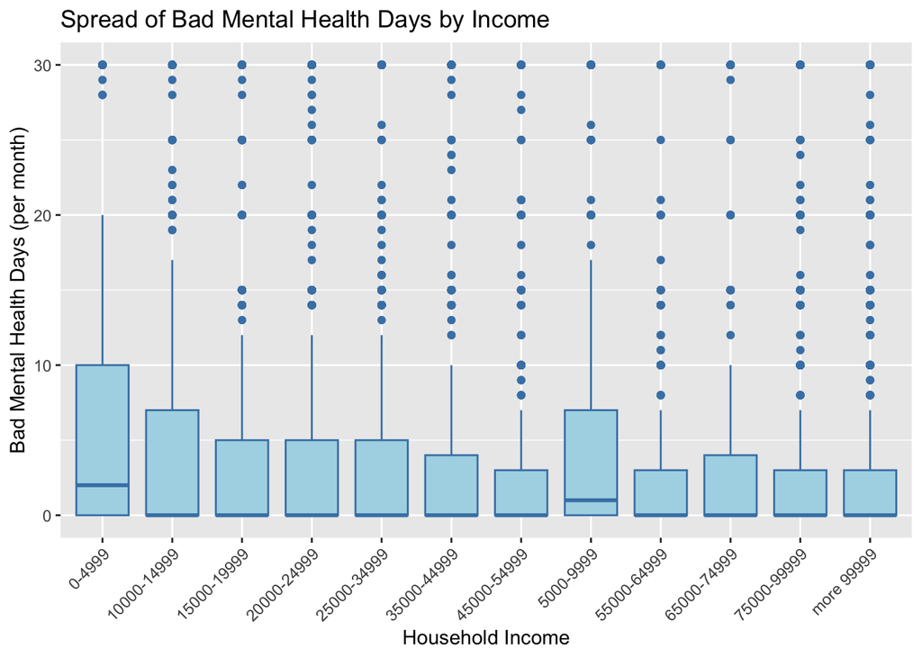

# Question 6: What are the factors which might influence sleep quality?

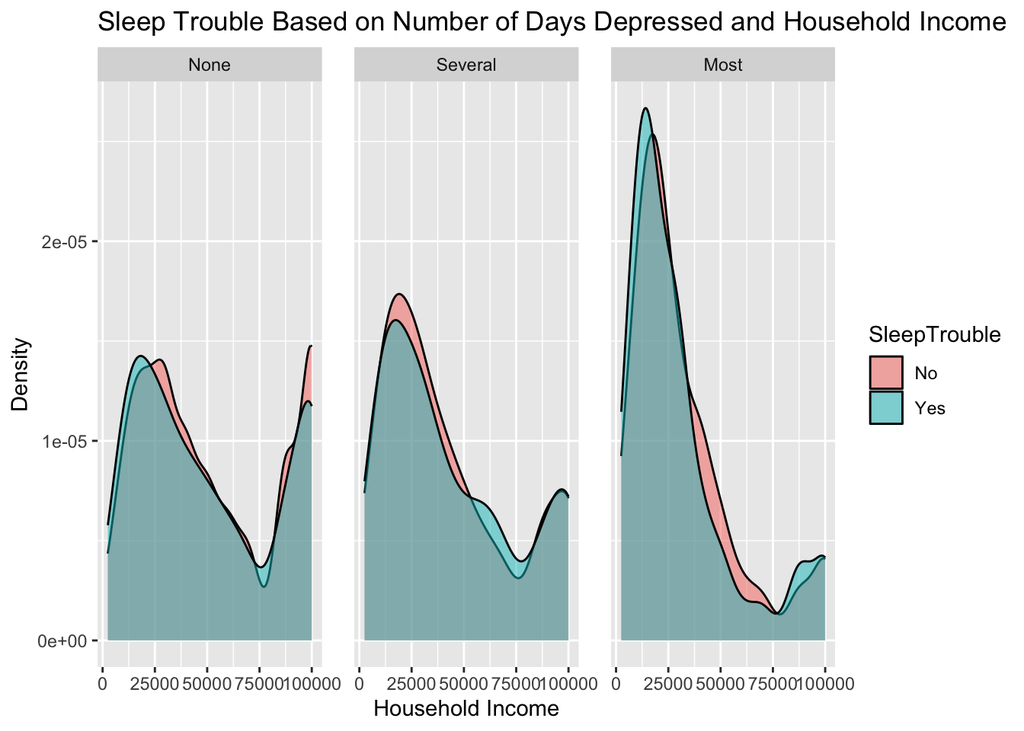

To understand the question of which factors influence sleep quality, the best measure within the dataset would have to be Sleep Trouble. Knowing this, it made sense to compare it against two factors which we predicted to have some influence: depression and household income. Our hypothesis was that a higher household income would lead to a higher sleep quality and less sleep trouble, while increased amount of days depressed would increase sleep trouble. By measuring the frequency of these, we hoped to be able to identify some trends between the different factors. After plotting, however, it seems that sleep trouble does not really change based on household income, as the densities remain very similar. However, we can notice a trend between lower income and higher depression, which actually related to our 5th question. Overall though, we were unable to find any discernible trend when it comes to sleep quality.

2. Create 6-10 figures from the data exploring your questions.
   - at least one figure must be faceted using `facet_`
   - each counted figure must be multivariate and show at least two of the plotting techniques we learned in class
   - all figures must be well-labeled
   - no more than two figures of the same type (counted using `geom_`, if you include $>8$ figures, you are allowed to have more than 2 of a given type)
3. Write a report with your figures included.

## Submission

- A `zip` file consisting of one `RMD` and one `HTML` files. The name of your `zip` file should be a two-digit number corresponding to your group.
- The knitted output of the `RMD` file must be identical to the `HTML` file.
- The `HTML` file should only consist of words and plots, i.e., no code. To do this, you can set `echo = F` in the global options.

## Grading structure

The precise rubric will be published via ELMS. You will be graded on:

1. Basic completion according to the instruction
2. Depths of your guiding questions
3. Suitable plot types
4. Meaningful statistical analysis/transforms to support your questions and provide additional insights
5. Statistical rigor, including but not restricted to: expressing uncertainty, explanation why/how the methods work, reproducibility of the experiments

## Group Structure

The following applies to a standard 3-person group. I will make suitable adjustment for the non-standard group.

| Role | Responsibilities |
| --- | --- |
| **Project Leader/Manager** | - Guides the overall direction of the EDA project - Organizes workflow, deadlines, communication (with team members and the instructor), and file submission |
| **Data/Stat Lead** | - Performs data cleaning, transformations, and statistical analysis - Provides technical support to others |
| **Visualization/Communication Lead** | - Designs clear, well-labeled, and statistically informed figures - Standardizes figures/texts and integrate them into report |
| **All Members** | - Each member is responsible for at $\geq 2$ plots, and must draft texts for their own plots - Each member is responsible for writing a post-production report |

> **Note:** Roles have some degree of flexiblility; members can overlap responsibilities. Every member must contribute technically, write text, and support quality control.

## Post-production

Each member is required to submit a report including an individual reflection and a group member evaluation. Both will be available only to the instructor/grader. Each report must include the following key information:

- Your roles and your plots (1 paragraph)
- Summary of your work (1 paragraph)
- Evaluation of each of your team member’s work, i.e., what aspects are done well and what could be improved for each member. (1 paragraph for each member)